# PCA

#### 1. The first step we do is to import the dataset and save it to a dataframe. We also set a seed for future reproductivity

#### 2. The second step we do is to split the train and test set

#### 3. Next we will start our principle component analysis

#### I. Choose principal components

center and scale data set

```
## [1] 6497   12
```

calculate the eigenvalue for the wine data set

```
##  [1] 3.80939755 2.52874763 1.56149944 0.97083829 0.72381327 0.61354055
##  [7] 0.53636608 0.50298441 0.35245239 0.25683224 0.11938090 0.02414725
```

make sure that the sum of the eigenvalues equals the total variance of the sample data.

```
## [1] TRUE
```

calculate the proportion of the total variance for each particular eigenvalue.

```
##  [1] 0.317449796 0.210728969 0.130124953 0.080903191 0.060317772 0.051128379
##  [7] 0.044697173 0.041915367 0.029371032 0.021402687 0.009948408 0.002012271
```

How many principal components are needed?

We will introduce the following three simple approaches.

1. the visual examination of a scree plot
2. the variance explained criteria
3. the Kaiser rule.

The visual examination of a scree plot

By observing the scree plot, and looking for a point at which the proportion of variance explained by each subsequent principal component drops off. This is often referred to as an elbow in the scree plot.

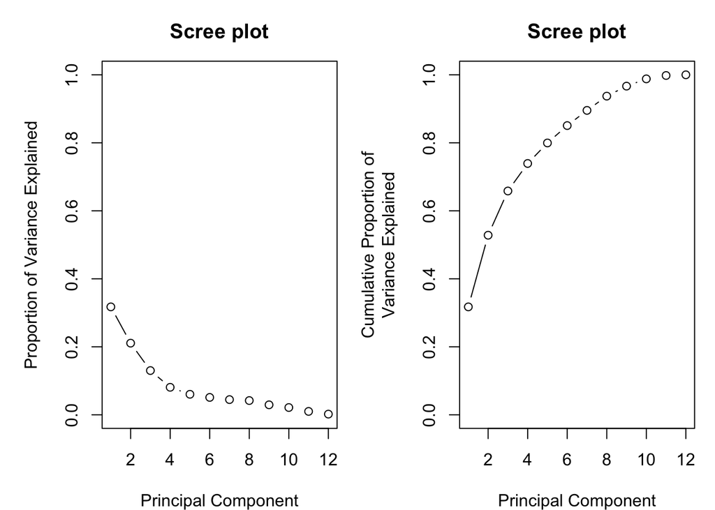

By looking at the plots we see a drop off (elbow in the scree plot) after the fourth principal component. Thus, based on the scree plot we would decide to pick the first five principal component to represent our data set, thereby explaining 80% of the variance in the data set.

Another approach to choose the number of principal components is to set a threshold, say 90%, and stop when the first k components account for a percentage of total variation greater than this threshold. In our example the first eight components account for 93.7% of the variation. Thus, based on the variance explained criteria we pick the first eight principal components to represent our data set.

```
##  [1] 0.3174498 0.5281788 0.6583037 0.7392069 0.7995247 0.8506531 0.8953502
##  [8] 0.9372656 0.9666366 0.9880393 0.9979877 1.0000000
```

Kaiser’s rule (Kaiser-Guttman criterion) only those principal components whose variances exceed 1 are retained

```
## [1] 3.809398 2.528748 1.561499
```

#### II. Prediction with Principal Components

```
## Call:
## multinom(formula = quality ~ PC1 + PC2 + PC3, data = trg)
##
## Coefficients:
##   (Intercept)         PC1         PC2       PC3
## 4    2.045742  0.05206739  0.30042799 0.2307270
## 5    4.285533 -0.01206055 -0.02934119 0.1750774
## 6    4.719147 -0.12465087  0.30384894 0.4555426
## 7    3.520920 -0.14234970  0.65878620 0.7082665
## 8    1.646668 -0.37773756  0.74107786 0.6252388
## 9   -2.777056 -0.50544448  1.16354433 1.0255696
##
## Std. Errors:
##   (Intercept)        PC1       PC2       PC3
## 4   0.2386441 0.09313310 0.1382760 0.1672084
## 5   0.2272755 0.08715738 0.1294883 0.1583768
## 6   0.2266879 0.08727963 0.1294695 0.1583764
## 7   0.2292238 0.08927064 0.1312558 0.1603563
## 8   0.2496544 0.10870041 0.1406455 0.1743783
## 9   1.0255244 0.55326861 0.4269664 0.5040213
##
## Residual Deviance: 13799.9
## AIC: 13847.9
```

Confusion Matrix & Misclassification Error – training

```
##
## p      3    4    5    6    7    8    9
##   3    0    0    0    0    0    0    0
##   4    0    0    0    0    0    0    0
##   5   16   59  919  662  112   17    0
##   6   12  127  983 1861  825  149    5
##   7    0    3    4   45   39    9    0
##   8    0    0    0    0    0    0    0
##   9    0    0    0    0    0    0    0
```

```
## [1] 0.5178724
```

Misclassification for the training data set is 0.5178724

Confusion Matrix & Misclassification Error – testing

```
##
## p1    3   4   5   6   7   8
##   3   0   0   0   0   0   0
##   4   0   0   0   0   0   0
##   5   2  11 105  76  11   0
##   6   0  16 126 186  89  17
##   7   0   0   1   6   3   1
##   8   0   0   0   0   0   0
##   9   0   0   0   0   0   0
```

```
## [1] 0.5476923
```

Misclassification for the testing data set is 0.5476923

Interpretation of misclassification error

```r
summary(as.factor(train$quality))
```

```
##    3    4    5    6    7    8    9
##   28  189 1906 2568  976  175    5
```

One of the potential interpretation for why there is no prediction for quality 3, 4, 8, 9 is that the number of data for these quality levels is comparatively low so that the prediction of the model on these levels does not perform as well as quality 5, 6 which have more data to train.